# hw2b

```r
# Question 8
# a
test_data <- naref(test_data)
training_data <-naref(training_data)

# b
X <- model.matrix(~ .,data = training_data)[,-1]
```

# Question 9:

# b:

# c:

larger the lambda the larger the penalty which means less complexity which increase the bias and the variance decrease

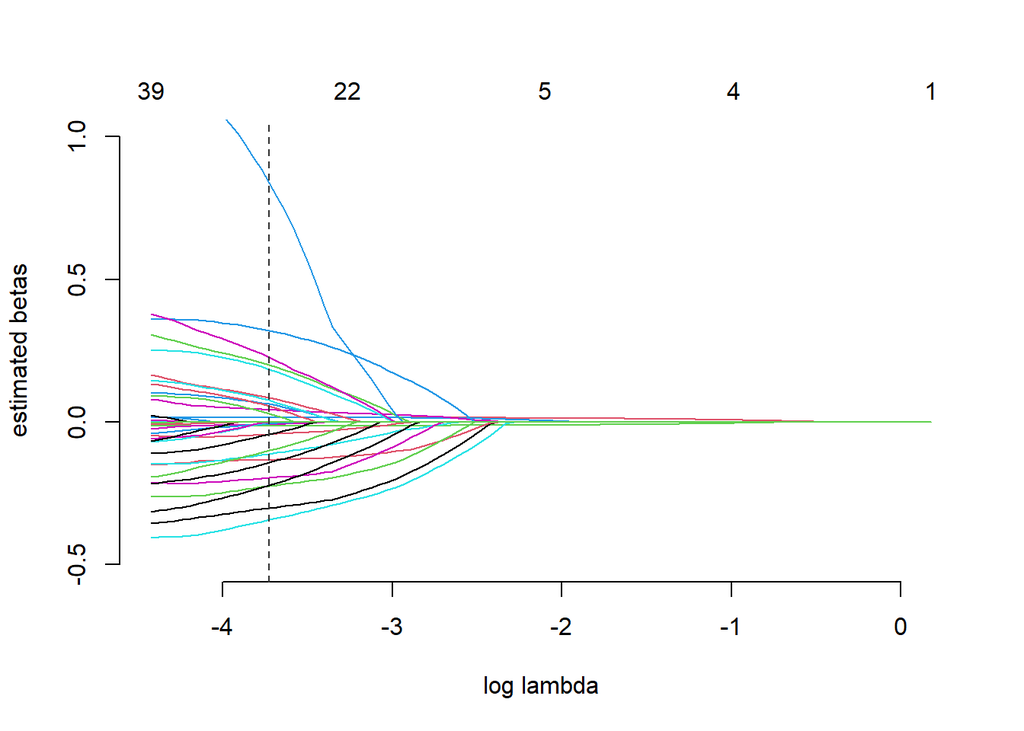

```r
# Question 9
# a
lasso_model <- gamlr(X, log(training_data$Salary))

plot(lasso_model, ylab="estimated betas", ylim = c(-0.5, 1))
```

# Question 10:

“CV gives us K estimates of the sample deviance, one for each of the held out folds”. we are looking for the lambda with lowest sample deviance. we understand that the r-squared represents the proportion of the variance for a dependent variable. So when we have a higher r-squared we have more variance and lower bias and more complex model. So as our model close to 0 we see an increase in variance and lower bias.

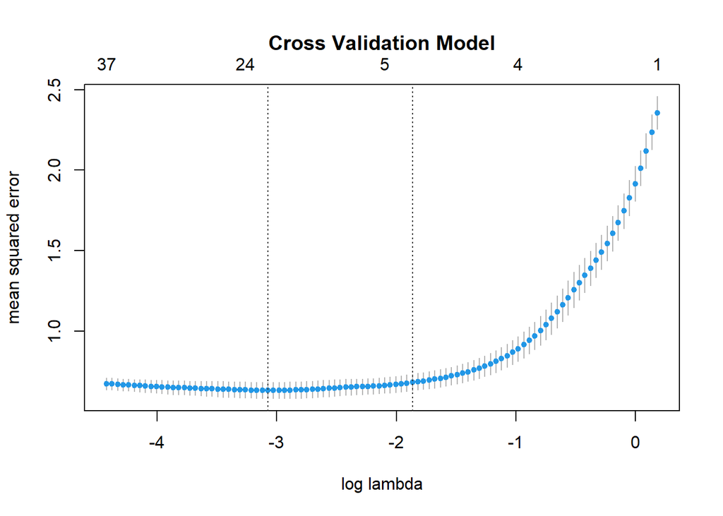

```r
# Question 10
set.seed(0)
cv.X <- model.matrix(~ ., data = data_omit_usa_subset)[,-1]
cv.lasso_model <- cv.gamlr(cv.X, log(data_omit_usa_subset$Salary))
plot(cv.lasso_model, main = "Cross Validation Model")
```

#Question 11: STL. has the highest everything else of the following stats: TRB, AST, BLK, BPM is a 0

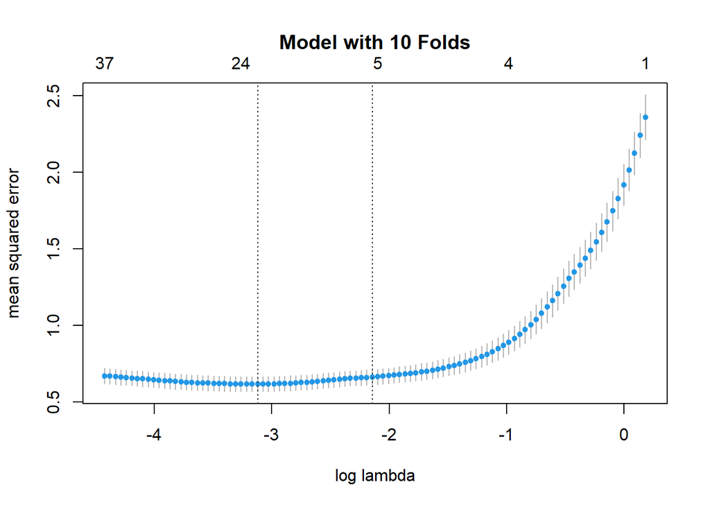

```r
set.seed(0)
cv.lasso_model_10 <- cv.gamlr(cv.X, log(data_omit_usa_subset$Salary), nfold = 10)
plot(cv.lasso_model_10, main = "Model with 10 Folds")
```

```r
cv.betas <- coef(cv.lasso_model_10$gamlr)[-1,]
nonzeros <- cv.betas[which(cv.betas!=0)]
cv.betas["TRB."]
```

```
## TRB.
##    0
```

```r
cv.betas["AST."]
```

```
## AST.
##    0
```

```r
cv.betas["STL."]
```

```
##         STL.
## -0.007518071
```

```r
cv.betas["BLK."]
```

```
## BLK.
##    0
```

```r
cv.betas["BPM"]
```

```
## BPM
##   0
```

```r
nonzeros
```

```
##          Salary NBA_DraftNumber             Age           TmBOS           TmBRK
##    1.361804e-07   -1.409276e-02    1.672139e-02   -3.855055e-02    5.629708e-02
##           TmCHI           TmDAL           TmDEN           TmDET           TmGSW
##    1.772078e-01   -1.432077e-01    1.200443e-01    3.357221e-01   -1.617706e-01
##           TmHOU           TmIND           TmLAL           TmMEM           TmMIA
##    9.071144e-02    2.267673e-01   -3.337591e-01   -1.779883e-01    1.125994e-01
##           TmMIN           TmNYK           TmPHI           TmUTA               G
##    2.644846e-01    1.342008e-01   -1.336814e-01   -2.814766e-01    1.711227e-02
##             PER             TS.             FTr            DRB.            STL.
##   -8.522180e-03    6.632602e-01   -9.226897e-02    9.943126e-04   -7.518071e-03
##             OWS            DBPM            VORP
##   -4.864373e-02    3.981181e-02   -1.143707e-01
```

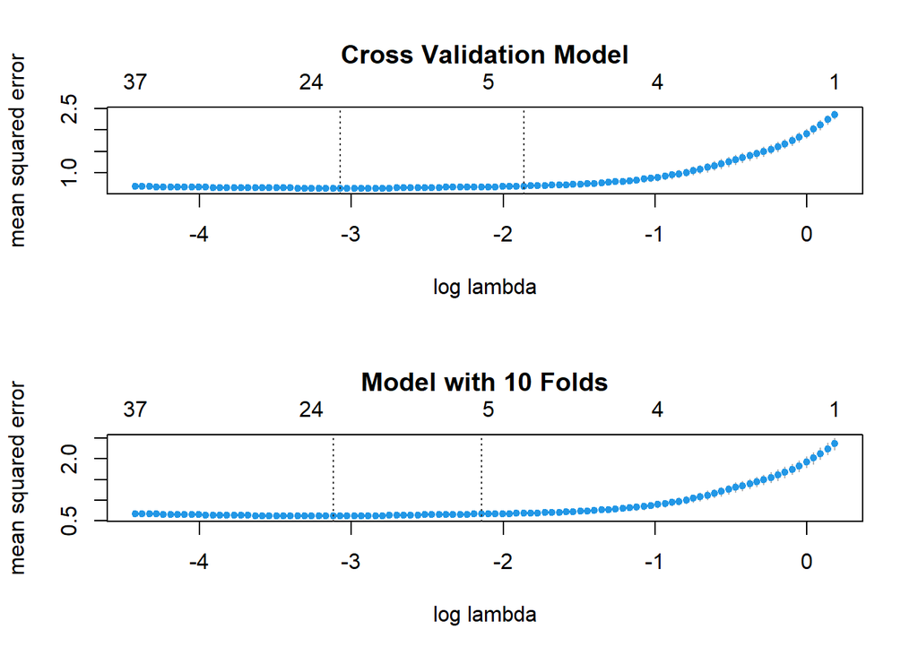

```r
par(mfrow=c(2,1))
plot(cv.lasso_model, main = "Cross Validation Model")
plot(cv.lasso_model_10, main = "Model with 10 Folds")
```

# Question 12:

```r
# Question 12
betas <- coef(lasso_model)[-1,]
aicc.nonzeros <- betas[which(cv.betas!=0)]
betas
```

```
##          Salary NBA_DraftNumber             Age           TmATL           TmBOS
##    1.382810e-07   -1.316885e-02    1.653518e-02   -9.964013e-02   -4.250147e-02
##           TmBRK           TmCHI           TmCHO           TmCLE           TmDAL
##    2.968011e-02    1.851795e-01    0.000000e+00    0.000000e+00   -2.245289e-01
##           TmDEN           TmDET           TmGSW           TmHOU           TmIND
##    8.603436e-02    3.210953e-01   -1.420962e-01    7.596306e-02    2.006242e-01
##           TmLAC           TmLAL           TmMEM           TmMIA           TmMIL
##    0.000000e+00   -3.432735e-01   -1.951329e-01    6.265468e-02    0.000000e+00
##           TmMIN           TmNOP           TmNYK           TmOKC           TmORL
##    2.276065e-01    0.000000e+00    5.556998e-02    0.000000e+00    0.000000e+00
##           TmPHI           TmPHO           TmPOR           TmSAC           TmSAS
##   -2.212346e-01    0.000000e+00    0.000000e+00    0.000000e+00    0.000000e+00
##           TmTOR           TmTOT           TmUTA           TmWAS               G
##    0.000000e+00    0.000000e+00   -3.012812e-01    0.000000e+00    1.665648e-02
##              MP             PER             TS.           X3PAr             FTr
##    0.000000e+00   -7.985328e-03    8.394061e-01    0.000000e+00   -1.115703e-01
##            ORB.            DRB.            TRB.            AST.            STL.
##    0.000000e+00    0.000000e+00    0.000000e+00    0.000000e+00   -5.867311e-03
##            BLK.            TOV.            USG.             OWS             DWS
##    0.000000e+00    0.000000e+00    0.000000e+00   -4.289639e-02    0.000000e+00
##              WS           WS.48            OBPM            DBPM             BPM
##    0.000000e+00    0.000000e+00    0.000000e+00    4.317409e-02    0.000000e+00
##            VORP
##   -1.328180e-01
```

```r
cat("\n")
```

```r
cv.betas
```

```
##          Salary NBA_DraftNumber             Age           TmBOS           TmBRK
##    1.361804e-07   -1.409276e-02    1.672139e-02   -3.855055e-02    5.629708e-02
##           TmCHI           TmCHO           TmCLE           TmDAL           TmDEN
##    1.772078e-01    0.000000e+00    0.000000e+00   -1.432077e-01    1.200443e-01
##           TmDET           TmGSW           TmHOU           TmIND           TmLAC
##    3.357221e-01   -1.617706e-01    9.071144e-02    2.267673e-01    0.000000e+00
##           TmLAL           TmMEM           TmMIA           TmMIL           TmMIN
##   -3.337591e-01   -1.779883e-01    1.125994e-01    0.000000e+00    2.644846e-01
##           TmNOP           TmNYK           TmOKC           TmORL           TmPHI
##    0.000000e+00    1.342008e-01    0.000000e+00    0.000000e+00   -1.336814e-01
##           TmPHO           TmPOR           TmSAC           TmSAS           TmTOR
##    0.000000e+00    0.000000e+00    0.000000e+00    0.000000e+00    0.000000e+00
##           TmTOT           TmUTA           TmWAS               G              MP
##    0.000000e+00   -2.814766e-01    0.000000e+00    1.711227e-02    0.000000e+00
##             PER             TS.           X3PAr             FTr            ORB.
##   -8.522180e-03    6.632602e-01    0.000000e+00   -9.226897e-02    0.000000e+00
##            DRB.            TRB.            AST.            STL.            BLK.
##    9.943126e-04    0.000000e+00    0.000000e+00   -7.518071e-03    0.000000e+00
##            TOV.            USG.             OWS             DWS              WS
##    0.000000e+00    0.000000e+00   -4.864373e-02    0.000000e+00    0.000000e+00
##           WS.48            OBPM            DBPM             BPM            VORP
##    0.000000e+00    0.000000e+00    3.981181e-02    0.000000e+00   -1.143707e-01
```

```r
# Question 13
cat("IS Dev", lasso_model$deviance[which.min(lasso_model$deviance)], "\n", sep = " ")
```

```
## IS Dev 164.4719
```

```r
OOS <- model.matrix(~ .,data = test_data)[,-1]
pred_model <- predict(lasso_model, newdata = OOS)
OOS_dev <- 1 - (log(test_data$Salary) - pred_model)^2/(log(test_data$Salary) - mean(log(training_data$Salary)))
lasso_model_OOS <- gamlr(OOS, log(test_data$Salary))

cat("OOS Dev", lasso_model_OOS$deviance[which.min(lasso_model_OOS$deviance)], "or" , mean(OOS_dev), "\n", sep = " ")
```

```
## OOS Dev 0.895399 or 0.9082731
```

```r
OOS_dev
```

```
## 30 x 1 Matrix of class "dgeMatrix"
##         seg85
## 1   0.8006894
## 2   1.3158313
## 3  -0.3502100
## 4   0.5958732
## 5   0.7130463
## 6   1.2096195
## 7   0.9668408
## 8   1.1828238
## 9   1.0131001
## 10  0.9319547
## 11  2.1628734
## 12  0.9782515
## 13  0.6638598
```

[output cut: 17 more lines]

# Question 14:

# b:

831 inputs covariates with 100 segments, I would assume that the ols cant take an matrix with 100 segments

# c:

IS Dev 56.07471, OOS Dev 0.1123694

```r
# Question 14
# a
X_inter <- model.matrix(~ . + Tm*., data = training_data)[,-1]
lasso_model_inter <- gamlr(X_inter, log(training_data$Salary))
cat("IS Dev", lasso_model_inter$deviance[which.min(lasso_model_inter$deviance)], "\n", sep = " ")
```

```
## IS Dev 56.07471
```

```r
OOS_inter <- model.matrix(~ . + Tm*.,data = test_data)[,-1]
pred_model_inter <- predict(lasso_model_inter, newdata = OOS_inter)
OOS_inter_dev <- 1 - (log(test_data$Salary) - pred_model_inter)^2/(log(test_data$Salary) - mean(log(training_data$Salary)))
lasso_model_OOS_inter <- gamlr(OOS_inter, log(test_data$Salary))
cat("OOS Dev", lasso_model_OOS_inter$deviance[which.min(lasso_model_OOS_inter$deviance)], "or", mean(OOS_inter_dev),"\n", sep = " ")
```

```
## OOS Dev 0.1123694 or 1.105383
```

```r
OOS_inter_dev
```

```
## 30 x 1 Matrix of class "dgeMatrix"
##         seg75
## 1   0.6226606
## 2   1.1257967
## 3  -0.1009469
## 4   0.7202717
## 5   0.4664964
## 6   1.0932212
## 7   0.9995132
## 8   1.2824874
## 9   1.2659156
## 10  0.8782848
## 11  2.6117540
## 12  0.9995731
## 13  0.9265248
```

[output cut: 17 more lines]

# Question 15:

According to the AICc LeBron James is overpaid whether we include interaction or not while our CV model at non specific K-fold and k-fold 10 he is considered underpaid

```r
#lebron <- cv.X[data_omit_usa_subset$Salary == 33285709,]
new_pred_model <- predict(lasso_model, newdata = X)
cv.pred_model <- predict(cv.lasso_model, newdata = cv.X)
cv.pred_model_10 <- predict(cv.lasso_model_10, newdata = cv.X)
pred_model_inter <- predict(lasso_model_inter, newdata = X_inter)
exp(new_pred_model[which(data_omit_usa_subset$Salary == 33285709)])
```

```
## [1] 6119682
```

```r
exp(pred_model_inter[which(data_omit_usa_subset$Salary == 33285709)])
```

```
## [1] 5841917
```

```r
exp(cv.pred_model[which(data_omit_usa_subset$Salary == 33285709)])
```

```
## [1] 116519905
```

```r
exp(cv.pred_model_10[which(data_omit_usa_subset$Salary == 33285709)])
```

```
## [1] 134340854
```